# Proyecto 1: Análisis Exploratorio de Datos

Grupo 4: Dilary Sarahí, Sofía López, Fabian Prado, Humberto de la Cruz, Daniel Juárez

2026-02-16

### Repositorio: https://github.com/hadelacruz/proyecto1-analisis-exploratorio

# Descripción General del Conjunto de Datos

El conjunto de datos analizado corresponde a los registros de divorcios en Guatemala publicados por el INE. Se han unificado registros que abarcan un periodo superior a los 10 años para identificar patrones sociales a largo plazo.

Cantidad de observaciones: 66419 registros

Cantidad de variables: 19 variables

# Significado y Tipo de las Variables

A continuación se detallan las 19 variables principales del conjunto de datos:

Diccionario de Variables del Proyecto

| Variable | Significado | Tipo |
| --- | --- | --- |
| depreg | Departamento de registro | Categórica Nominal |
| mupreg | Municipio de registro | Categórica Nominal |
| mesreg | Mes de registro | Categórica Ordinal |
| anoreg | Año de registro | Numérica Discreta |
| diaocu | Día de la ruptura | Numérica Discreta |
| mesocu | Mes de la ruptura | Categórica Ordinal |
| depocu | Departamento del evento | Categórica Nominal |
| mupocu | Municipio del evento | Categórica Nominal |
| edadhom | Edad del esposo | Numérica Continua |
| edadmuj | Edad de la esposa | Numérica Continua |
| nachom | Nacionalidad (Hombre) | Categórica Nominal |
| nacmuj | Nacionalidad (Mujer) | Categórica Nominal |
| eschom | Escolaridad (Hombre) | Categórica Ordinal |
| escmuj | Escolaridad (Mujer) | Categórica Ordinal |
| ciuohom | Ciudad origen (Hombre) | Categórica Nominal |
| ciuomuj | Ciudad origen (Mujer) | Categórica Nominal |
| anioocu | Año del evento | Numérica Discreta |
| pueblo_hom | Pueblo de pertenencia del hombre (Etnia) | Categórica Nominal |
| pueblo_muj | Pueblo de pertenencia de la mujer (Etnia) | Categórica Nominal |

# Exploración de Variables Numéricas

Se analizan las variables cuantitativas mediante estadística descriptiva para entender el perfil de edad de la población.

### Medidas de Tendencia Central y Distribución

Resumen Estadístico: Tendencia Central, Distribución y Orden

|  | n | mean | sd | median | min | max | range | skew | kurtosis |
| --- | --- | --- | --- | --- | --- | --- | --- | --- | --- |
| edadhom | 35112 | 36.05 | 9.99 | 34 | 17 | 98 | 81 | 1.17 | 1.65 |
| edadmuj | 35160 | 32.84 | 9.10 | 31 | 15 | 81 | 66 | 1.05 | 1.30 |
| anioocu | 66419 | 2018.01 | 2.95 | 2018 | 2013 | 2022 | 9 | -0.20 | -1.24 |

### Determinación de la Distribución

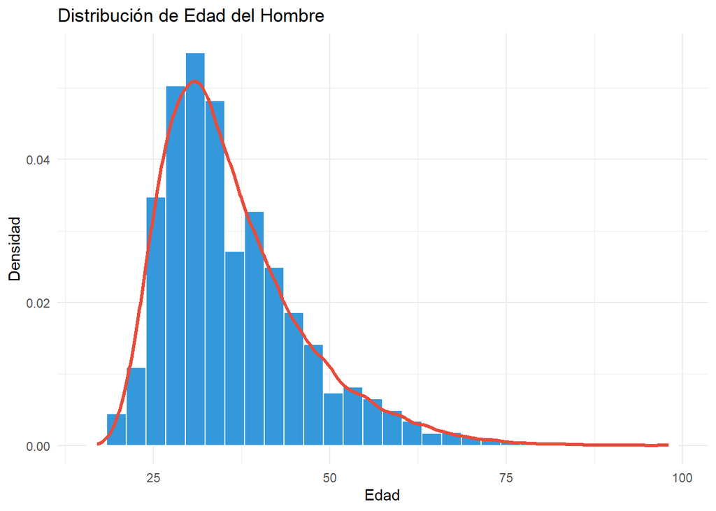

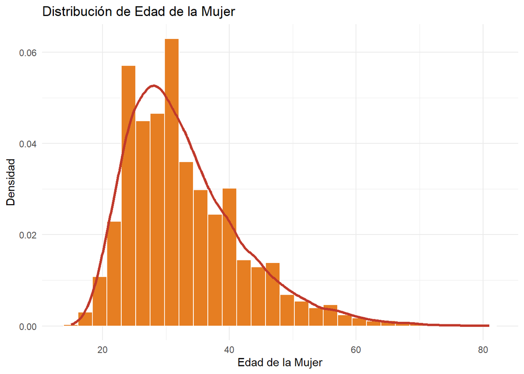

# Análisis de Distribución y Outliers

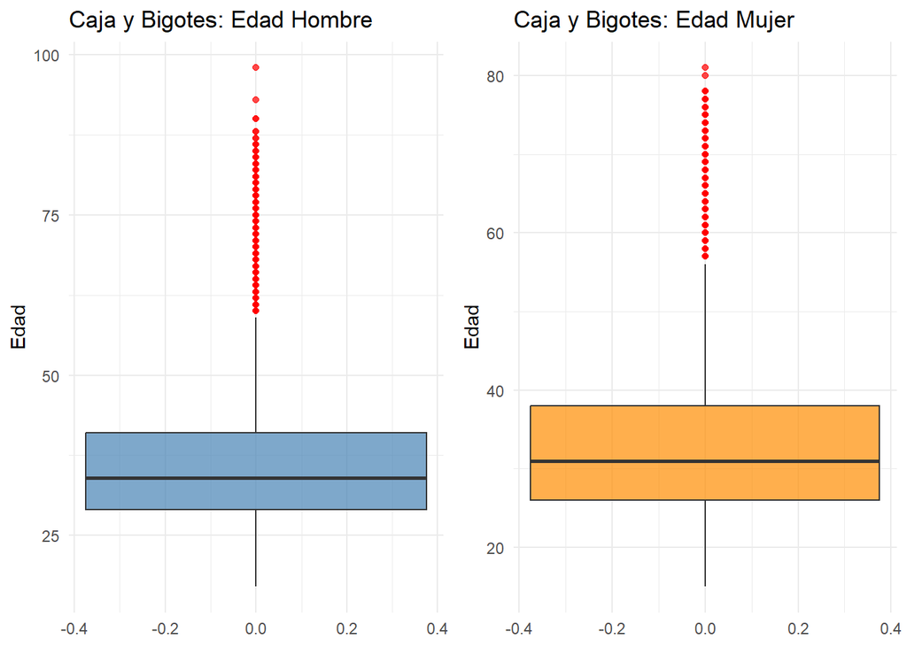

# Exploración de Variables Categóricas

Se utilizan tablas de frecuencia y proporciones para estudiar las variables cualitativas

### Frecuencia por Departamento

Top Departamentos con mayor número de divorcios

| Depto | n | percent |
| --- | --- | --- |
| Guatemala | 24378 | 36.7% |
| Quetzaltenango | 5115 | 7.7% |
| Escuintla | 3305 | 5.0% |
| San Marcos | 2915 | 4.4% |
| Jutiapa | 2795 | 4.2% |
| Suchitepequez | 2377 | 3.6% |
| Huehuetenango | 2321 | 3.5% |
| Izabal | 2094 | 3.2% |
| Santa Rosa | 1953 | 2.9% |
| Retalhuleu | 1920 | 2.9% |

### Frecuencia por Municipio de Ocurrencia

Top Municipios con mayor número de divorcios

| Municipio | n | percent |
| --- | --- | --- |
| Guatemala | 16207 | 24.4% |
| Mixco | 2137 | 3.2% |
| Quetzaltenango | 1946 | 2.9% |
| Villa Nueva | 1841 | 2.8% |
| Coatepeque | 1166 | 1.8% |
| Puerto Barrios | 1078 | 1.6% |
| Mazatenango | 979 | 1.5% |
| Retalhuleu | 973 | 1.5% |
| Huehuetenango | 959 | 1.4% |
| Escuintla | 955 | 1.4% |
| Jalapa | 932 | 1.4% |
| Jutiapa | 927 | 1.4% |
| Amatitlán | 797 | 1.2% |
| Zacapa | 736 | 1.1% |
| Chiquimula | 697 | 1.0% |
| Cobán | 651 | 1.0% |
| Totonicapán | 600 | 0.9% |
| Antigua Guatemala | 598 | 0.9% |
| Santa Lucía Cotzumalguapa | 576 | 0.9% |
| Morales | 563 | 0.8% |
| Villa Canales | 553 | 0.8% |
| Chimaltenango | 538 | 0.8% |
| Santa Cruz del Quiché | 519 | 0.8% |
| Salamá | 459 | 0.7% |
| Malacatán | 457 | 0.7% |
| San Pedro Sacatepéquez | 449 | 0.7% |
| Petapa | 431 | 0.6% |
| Chinautla | 420 | 0.6% |
| Tiquisate | 419 | 0.6% |
| Santa Catarina Pinula | 405 | 0.6% |

### Frecuencia por Mes de Ocurrencia

| Mes | n | percent |
| --- | --- | --- |
| Enero | 4985 | 7.5% |
| Febrero | 5916 | 8.9% |
| Marzo | 6484 | 9.8% |
| Abril | 5327 | 8.0% |
| Mayo | 5786 | 8.7% |
| Junio | 5672 | 8.5% |
| Julio | 5940 | 8.9% |
| Agosto | 6091 | 9.2% |
| Septiembre | 5564 | 8.4% |
| Octubre | 6484 | 9.8% |
| Noviembre | 4550 | 6.9% |
| Diciembre | 3620 | 5.5% |

### Frecuencia por Escolaridad

| Escolaridad | n | percent |
| --- | --- | --- |
| Ninguno | 8330 | 12.5% |
| Primaria | 6282 | 9.5% |
| Básico | 5204 | 7.8% |
| Diversificado | 12859 | 19.4% |
| Universitario | 3632 | 5.5% |
| Postgrado | 91 | 0.1% |
| Ignorado | 30021 | 45.2% |

### Frecuencia por Pueblo de Pertenencia Hombre

Distribución Étnica Hombre

| pueblo_hom | n | percent |
| --- | --- | --- |
| Ignorado | 33898 | 51.0% |
| Ladino / Mestizo | 26933 | 40.6% |
| Maya | 5044 | 7.6% |
| Otro | 513 | 0.8% |
| Garífuna | 22 | 0.0% |
| Xinka | 9 | 0.0% |

### Frecuencia por Pueblo de Pertenencia Mujer

Distribución Étnica Mujer

| pueblo_muj | n | percent |
| --- | --- | --- |
| Ignorado | 33977 | 51.2% |
| Ladino / Mestizo | 27167 | 40.9% |
| Maya | 4675 | 7.0% |
| Otro | 567 | 0.9% |
| Garífuna | 22 | 0.0% |
| Xinka | 11 | 0.0% |

# Relaciones entre Variables

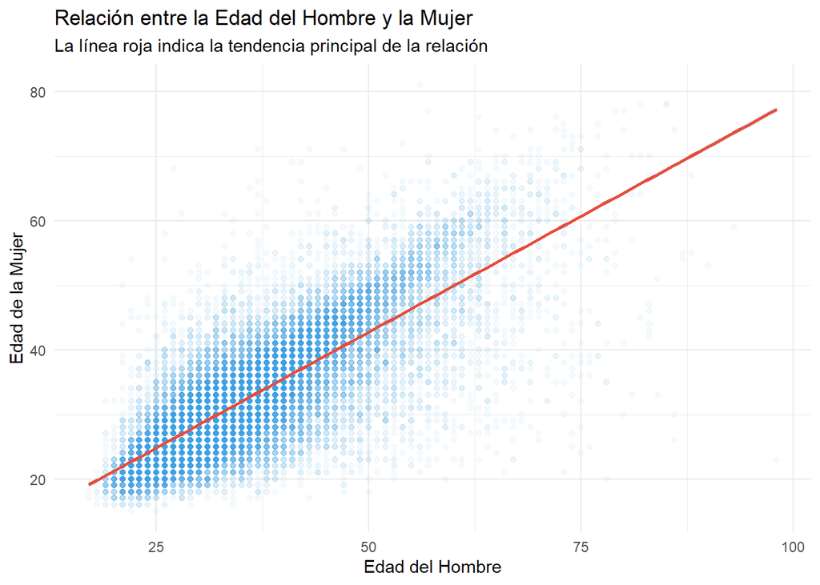

#CRUCE DE VARIABLES

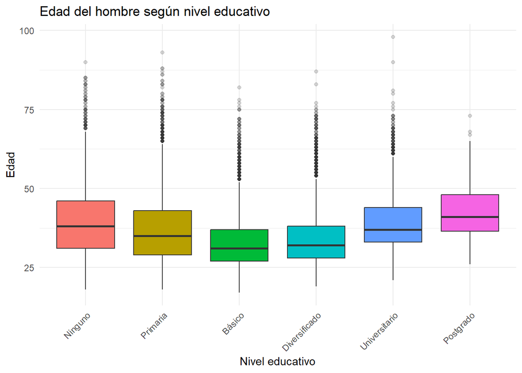

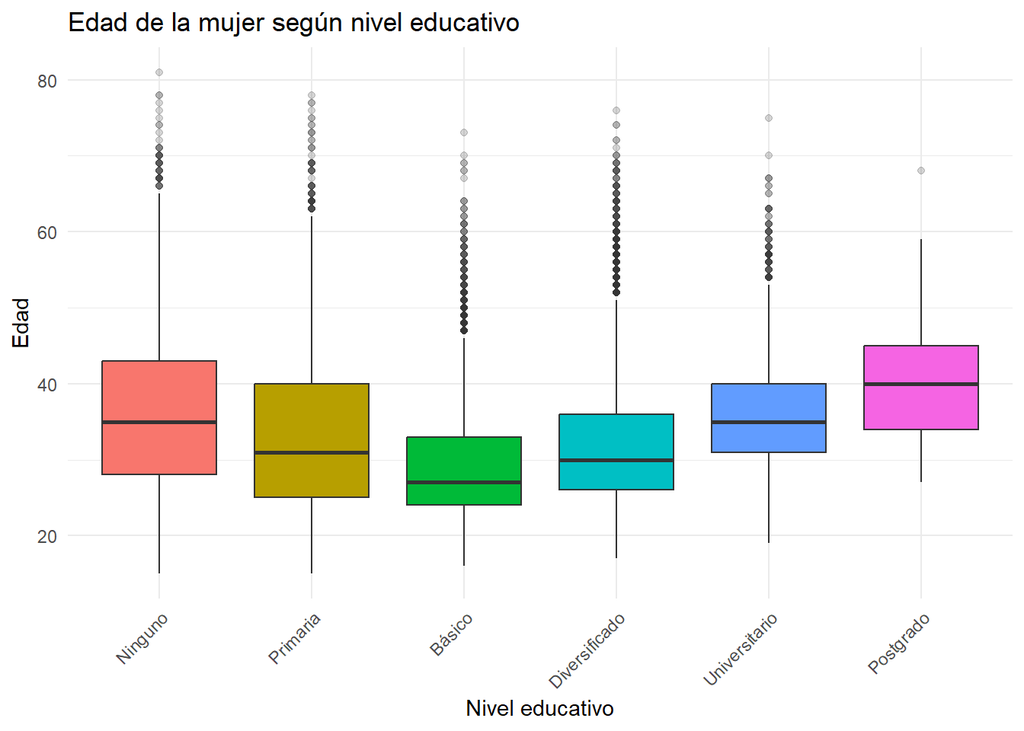

Por otro lado, en la gráfica de mujeres se observa un incremente progresivo desde básico hasta postgrado, el cual presenta las edades más altas y menos valores extremos. En esta gráfica se observa una asociación más fuerte entre el nivel educativo y la edad de la mujer. Indicando que las mujeres con postgrado tienden a divorciarse a mayor edad. Otro punto importante es que, en todos los niveles educativos, los hombres presentan una edad promedio mayor que las mujeres, marcando así una diferencia edad edades por género.

```
##    as_factor(depocu)  edadhom
## 1          Guatemala 36.71041
## 2        El Progreso 35.04107
## 3       Sacatepequez 36.25881
## 4      Chimaltenango 35.41368
## 5          Escuintla 36.07134
## 6         Santa Rosa 37.43698
## 7             Solola 33.89787
## 8        Totonicapan 31.96450
## 9     Quetzaltenango 36.18079
## 10     Suchitepequez 35.50122
## 11        Retalhuleu 34.64794
## 12        San Marcos 36.44613
## 13     Huehuetenango 35.38368
## 14            Quiche 33.40588
## 15      Baja Verapaz 35.18429
## 16      Alta Verapaz 36.20275
## 17             Peten 35.35097
## 18            Izabal 37.41511
## 19            Zacapa 35.93801
## 20        Chiquimula 36.17188
## 21            Jalapa 34.90355
## 22           Jutiapa 36.70515
```

```
##    as_factor(depocu)  edadmuj
## 1          Guatemala 33.96028
## 2        El Progreso 31.54660
## 3       Sacatepequez 33.11518
## 4      Chimaltenango 32.79720
## 5          Escuintla 32.54167
## 6         Santa Rosa 33.47725
## 7             Solola 30.85865
## 8        Totonicapan 29.55325
## 9     Quetzaltenango 33.32894
## 10     Suchitepequez 31.77815
## 11        Retalhuleu 31.37767
## 12        San Marcos 33.24291
## 13     Huehuetenango 32.36508
## 14            Quiche 29.64033
## 15      Baja Verapaz 31.81395
## 16      Alta Verapaz 32.59306
## 17             Peten 31.39899
## 18            Izabal 33.56422
## 19            Zacapa 31.64524
## 20        Chiquimula 32.19777
## 21            Jalapa 31.67778
## 22           Jutiapa 32.51046
```

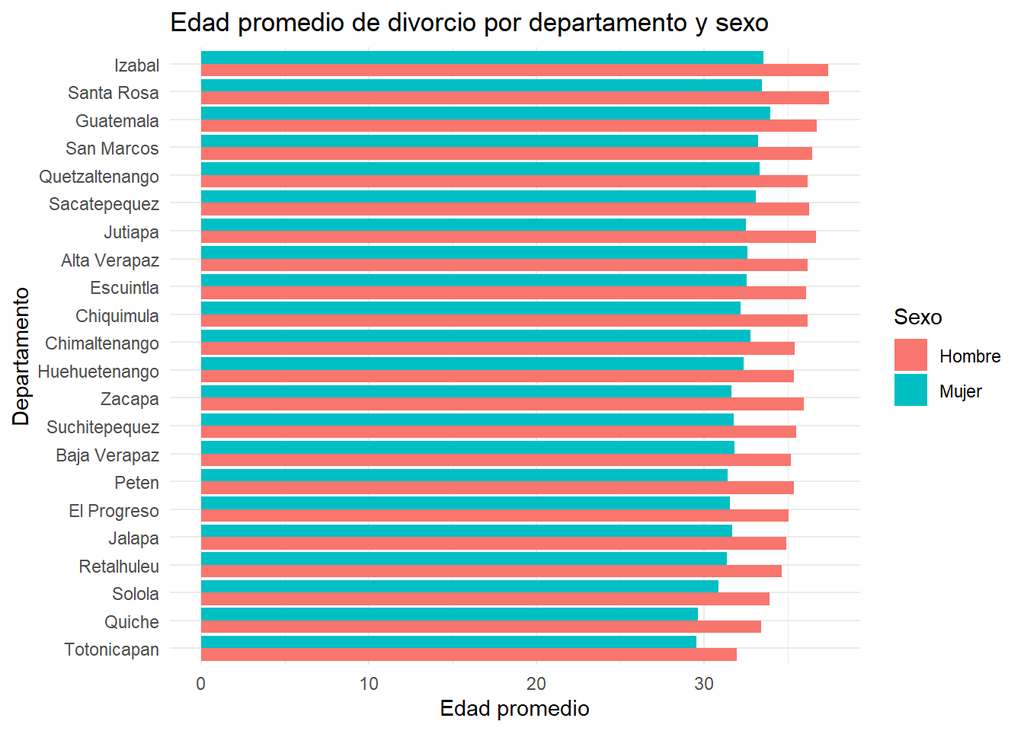

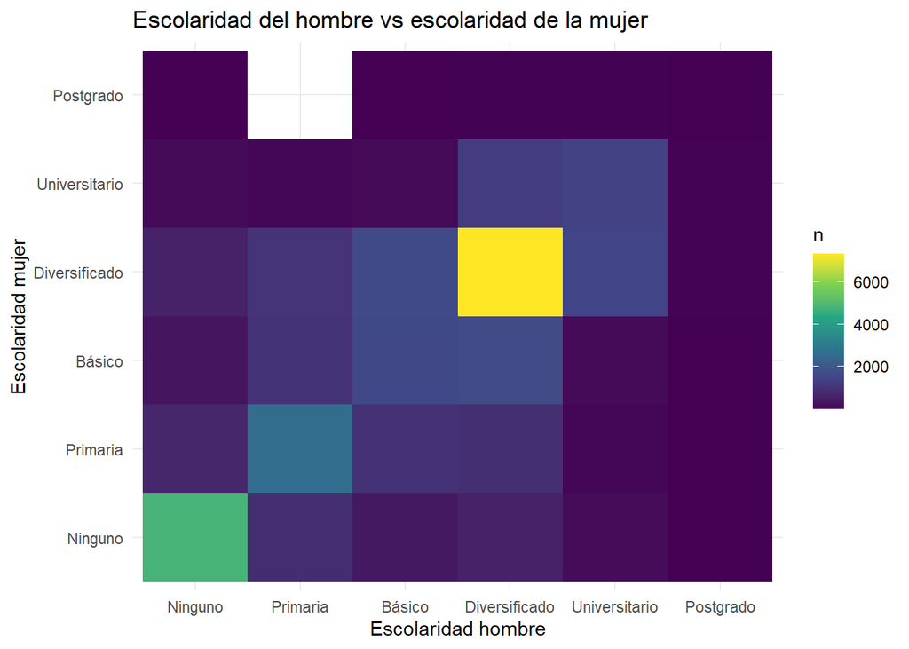

Al cruzar las variables de escolaridad del hombre y escolaridad de la mujer en los divorcios se puede observar que las parejas cuyo nivel educativo es ambos diversificado presentan mayor cantidad de divorcios. También se observa un patrón en la diagonal del gráfico, donde las parejas que se divorcian tienden a tener el nivel educativo igual o muy cercano. Por otro lado, mientras más separados están los niveles educativos entre el hombre y la mujer, menor es la cantidad de divorcios. Existen algunos niveles extremos como combinación entre “Ninguno” y “Postgrado”, los cuales son poco frecuentes. Esto sugiere que el nivel educativo de la pareja puede llegar a ser un factor importante al momento de tomar la decisión del divorcio.

#PREGUNTAS DE INVESTIGACION 1. ¿Es más frecuente el divorcio en las áreas más urbanas?

```
## # A tibble: 22 × 2
##    depocu             n
##    <fct>          <int>
##  1 Guatemala      24378
##  2 Quetzaltenango  5115
##  3 Escuintla       3305
##  4 San Marcos      2915
##  5 Jutiapa         2795
##  6 Suchitepequez   2377
##  7 Huehuetenango   2321
##  8 Izabal          2094
##  9 Santa Rosa      1953
## 10 Retalhuleu      1920
## # ℹ 12 more rows
```

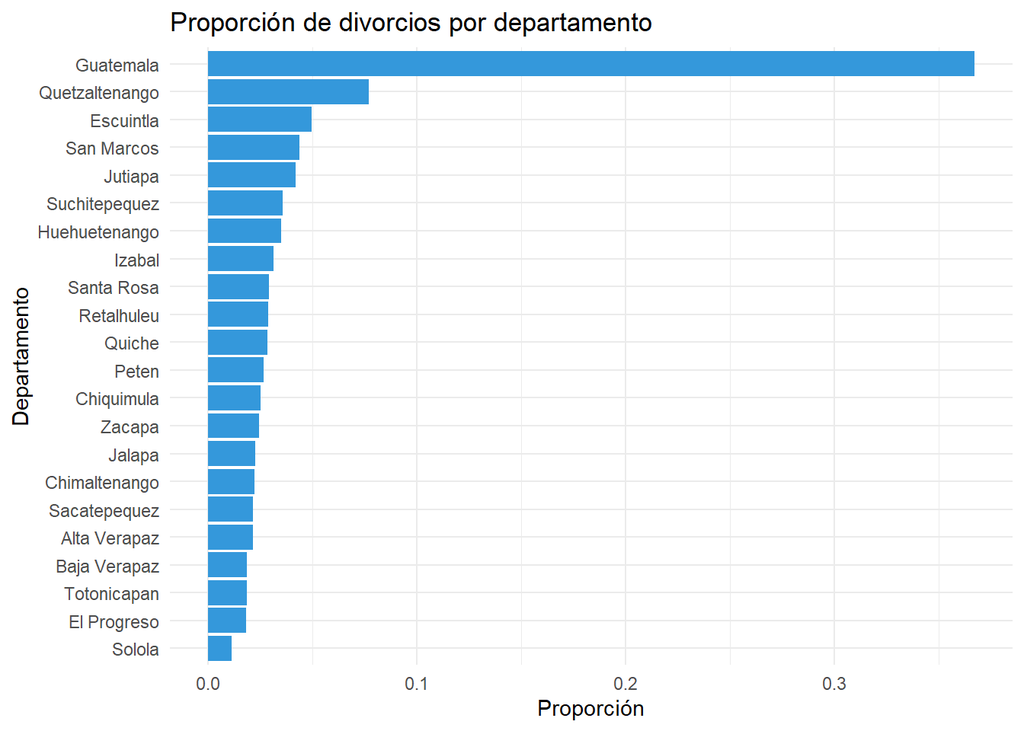

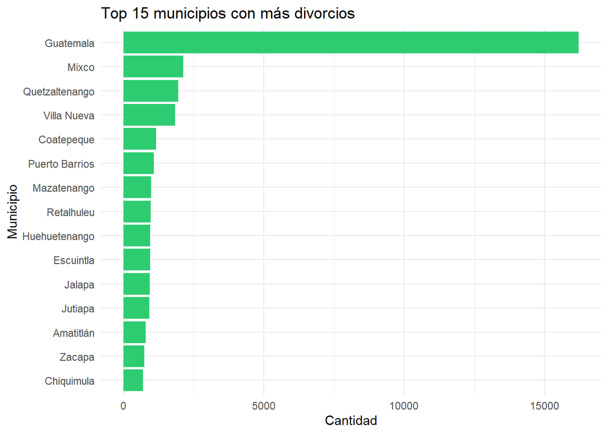

En la tabla se muestra es mas frecuente el divorcio en las áreas que están más urbanizadas, como lo es el departamento de Guatemala, que representa aproximadamente 35% del total de los divorcios registrados. Pasa lo mismo con los municipios, los municipios con mayor concentración de divorcios, como Guatemala, Mizco, Quetzaltenango y Villa Nueva, son áreas urbanas. Por lo tanto, según indican los resultados, si se podría decir que hay mayor tasa de divorcio en los sectores urbanos del pais.

2. ¿Las personas con mayor nivel educativo se divorcian a edades más avanzadas?

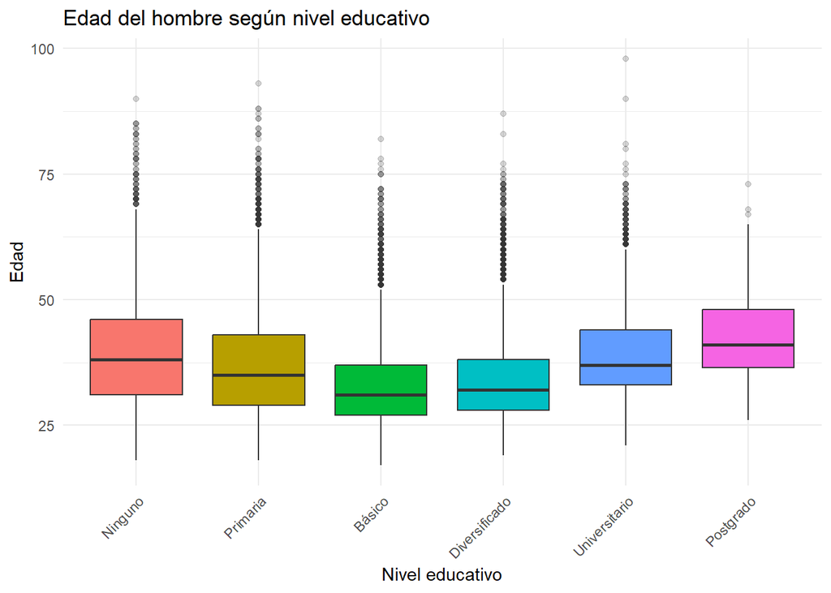

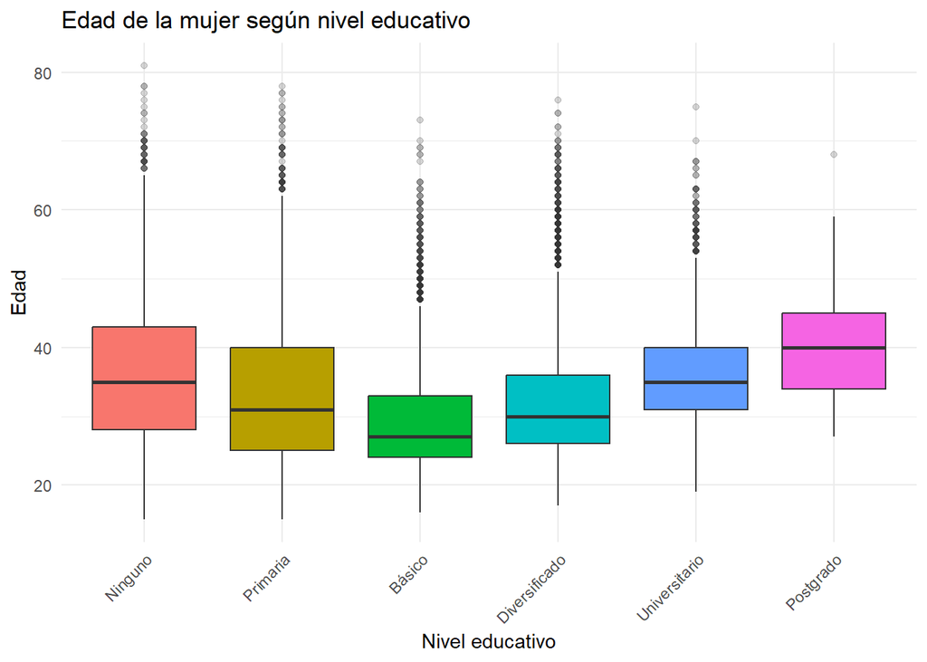

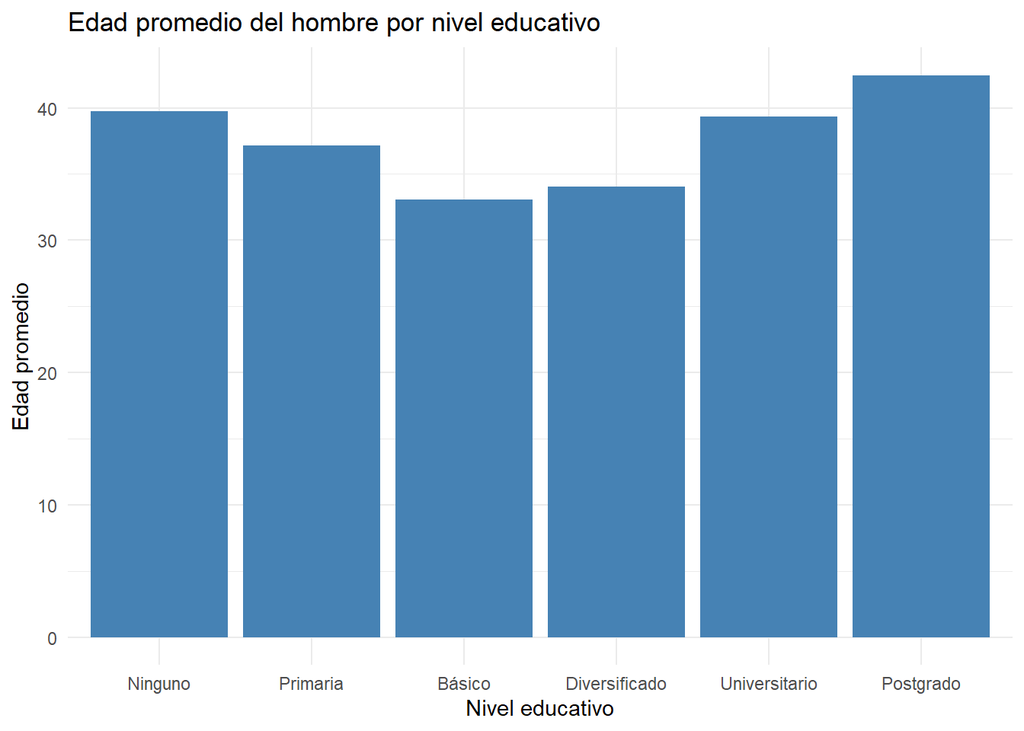

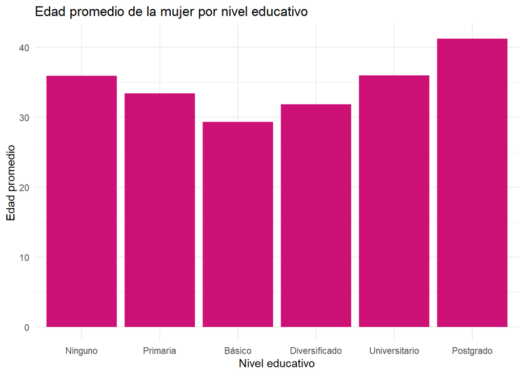

Los resultados muestran una relación positiva entre el nivel educativo y la edad promedio de divorcio, especialmente en los niveles “universitario” y “postgrado”. Se logra identificar que, en promedio, las personas con mayor nivel educativo tienden a divorciarse a edades más altas. No obstante, las cajas se encuentran muy cercanas entre las distribuciones, por lo que el nivel educativo no determina completamente la edad de divorcio, sino que es un factor asociado. Esto se observa ya que en ambos sexos aparece un patrón similar, aunque esta relación se ve más marcada en las mujeres.

3.¿La mayoria de los divorcios ocurre en parejas con diferencias de edad más altas?

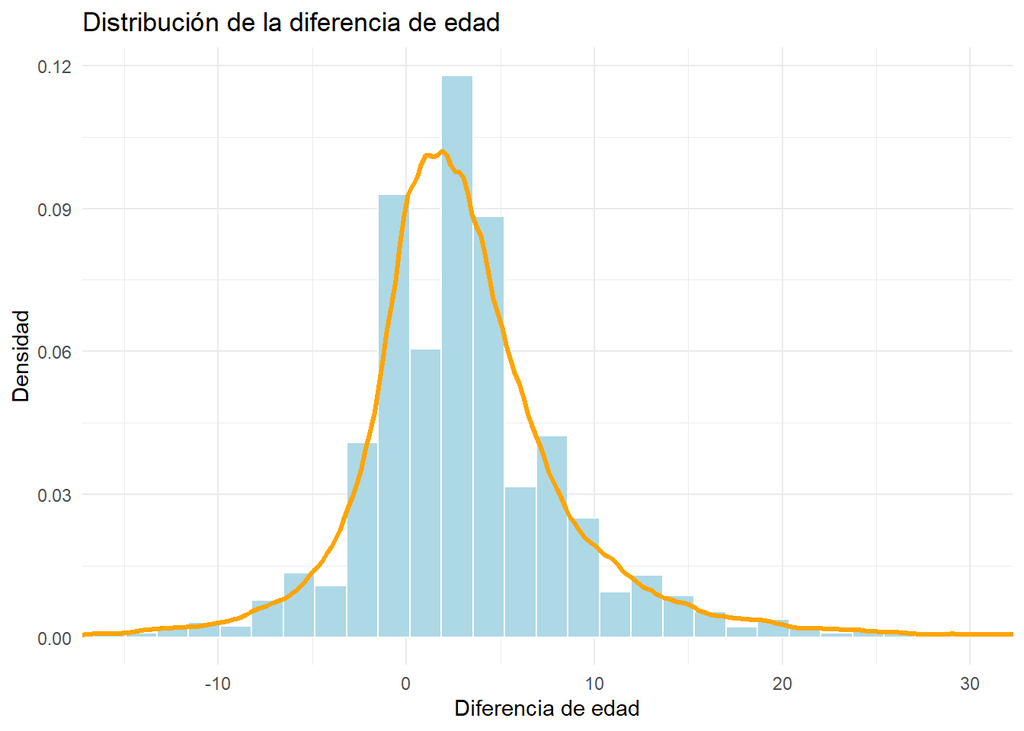

```
## # A tibble: 1 × 5
##   media mediana    sd   min   max
##   <dbl>   <dbl> <dbl> <dbl> <dbl>
## 1  3.16       2  6.06   -41    75
```

En la gráfica se muestra que la concentración está entre -5 y 5 años y que, a medida que la diferencia aumenta, la frecuencia de matrimonios va disminuyendo. De igual forma, se observa que las diferencias mayores a 15 años son menos frecuentes. También se puede ver que las estadísticas indican una mediana de 2 años, lo que significa que la mitad de las parejas tiene una diferencia de edad de alrededor de 2 años. La desviación estándar muestra que sí existe variabilidad, aunque no es excesiva. Por lo tanto, a partir de este análisis se puede concluir que la mayoría de los divorcios no ocurre en parejas con mayor diferencia de edad. Aunque existen valores extremos con diferencias muy altas, la mayor cantidad de divorcios presenta diferencias de edad pequeñas, por lo que se contradice el supuesto inicial.

4. ¿Las parejas que se divorcian tienden a tener niveles educativos similares?

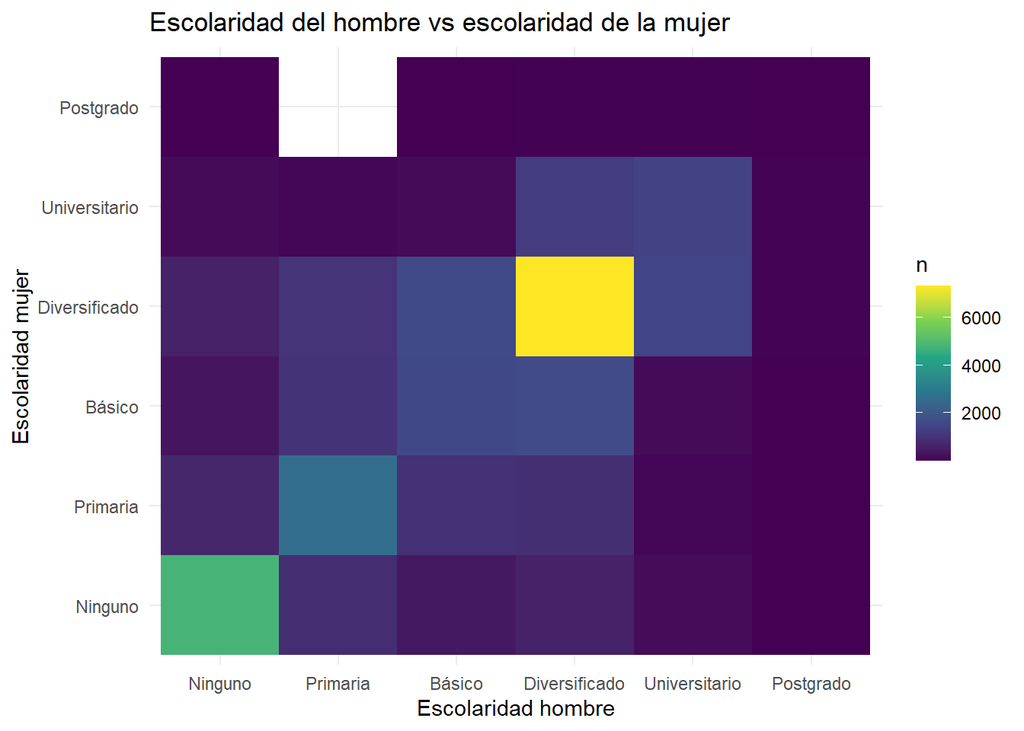

```
## # A tibble: 35 × 4
## # Groups:   eschom [6]
##    eschom   escmuj            n     prop
##    <fct>    <fct>         <int>    <dbl>
##  1 Ninguno  Ninguno        4823 0.730
##  2 Ninguno  Primaria        702 0.106
##  3 Ninguno  Básico          333 0.0504
##  4 Ninguno  Diversificado   590 0.0893
##  5 Ninguno  Universitario   151 0.0229
##  6 Ninguno  Postgrado         5 0.000757
##  7 Primaria Ninguno         873 0.156
##  8 Primaria Primaria       2610 0.465
##  9 Primaria Básico         1009 0.180
## 10 Primaria Diversificado  1035 0.185
## # ℹ 25 more rows
```

En la gráfica se puede observar que la mayoria de los divorcios están concentrados en la diagonal de la gráfica, donde ambos mienbros tienen el mismo nivel educativo, principalmente en el nivel de “Diversificado” De igual forma se muestra que donde los niveles educativos son muy distintos, las frecuencias son mas bajas. Por lo tanto, si se puede decir que las parejas que se divorcian tienden a tener el mismo nivel educativo o similar.

5. ¿La edad mediana de divorcio ha disminuido con el paso del tiempo?

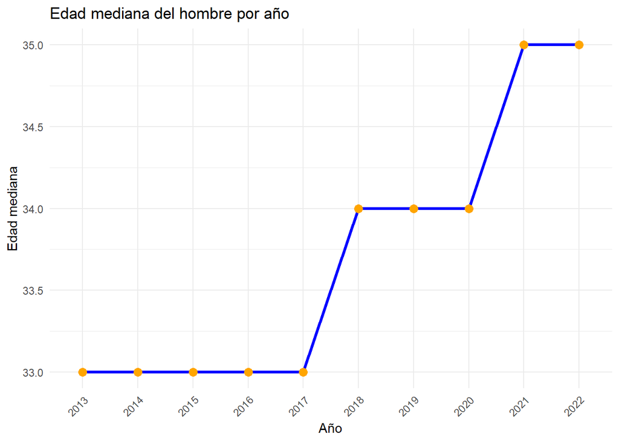

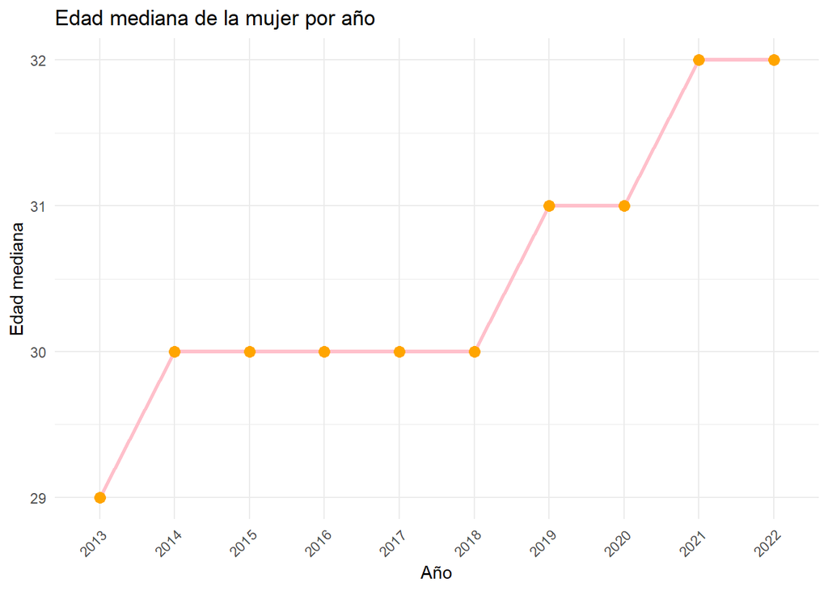

A partir de la gráfica de la edad mediana de divorcio por año, se observa que no existe una disminución con el paso del tiempo. En el caso de los hombres, la mediana se mantiene estable entre 2013 y 2017, y posteriormente presenta un ligero aumento hasta alcanzar los 35 años en 2021 y 2022. De igual forma, en las mujeres la mediana pasa de 29 años en 2013 a 32 años en los últimos años del período analizado. Por lo tanto, los datos contradicen el supuesto inicial, ya que no se evidencia una reducción en la edad mediana de divorcio, sino más bien una tendencia leve al aumento.

# GRAFICOS EXPLORATORIOS

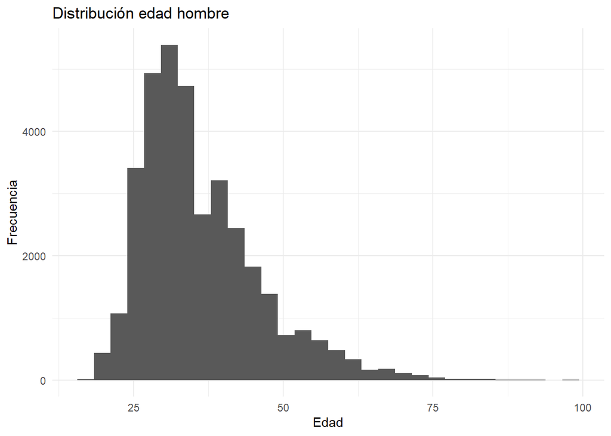

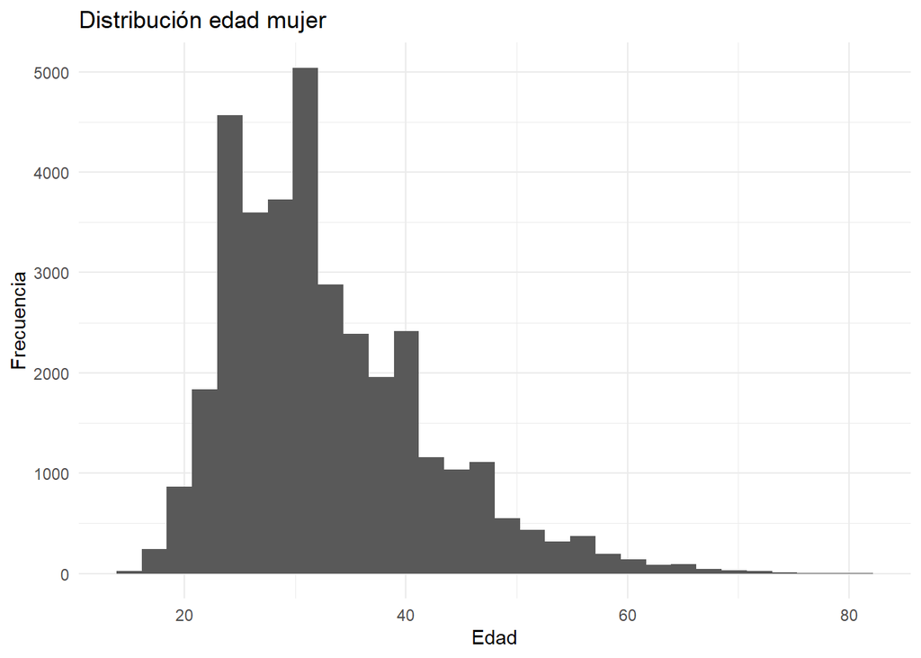

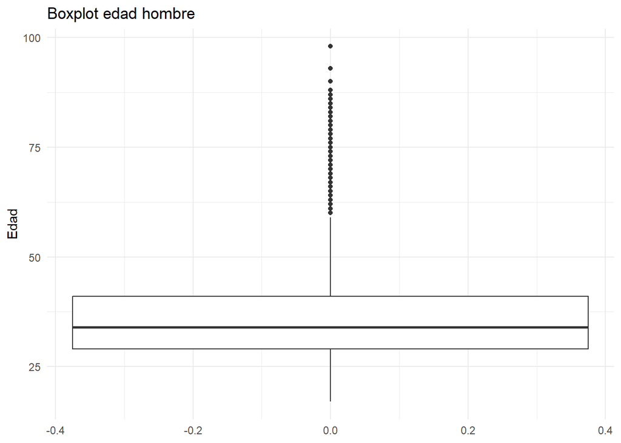

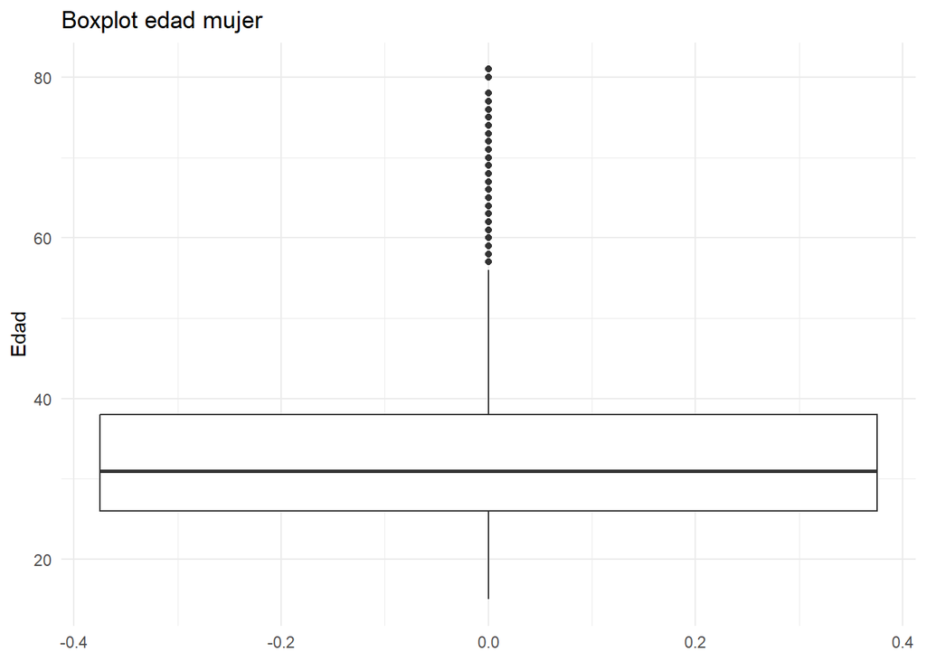

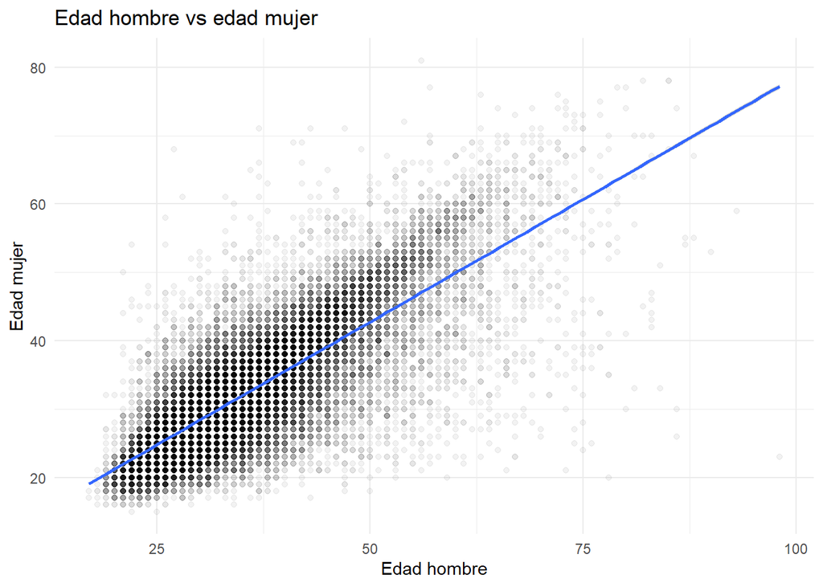

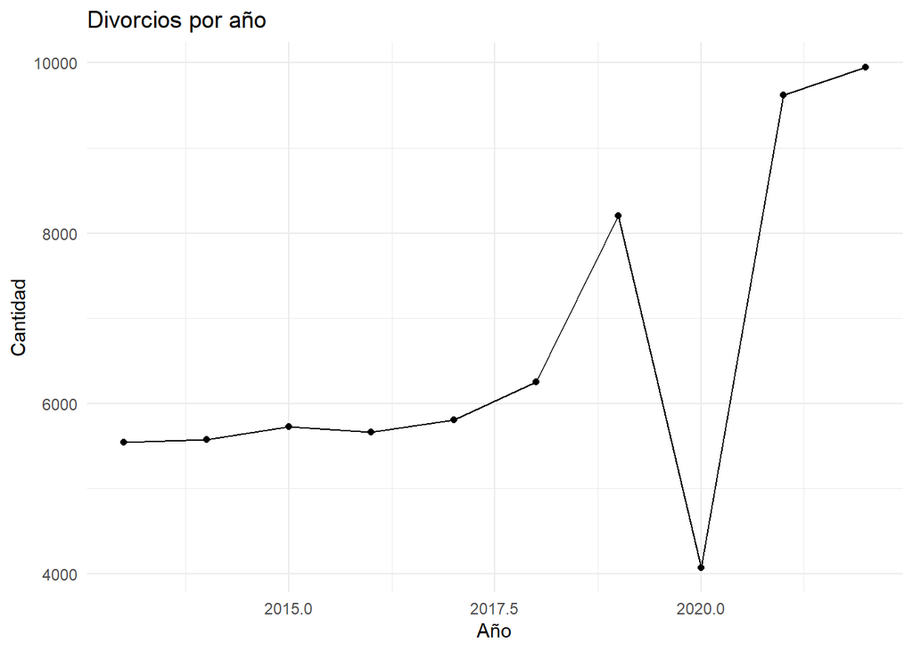

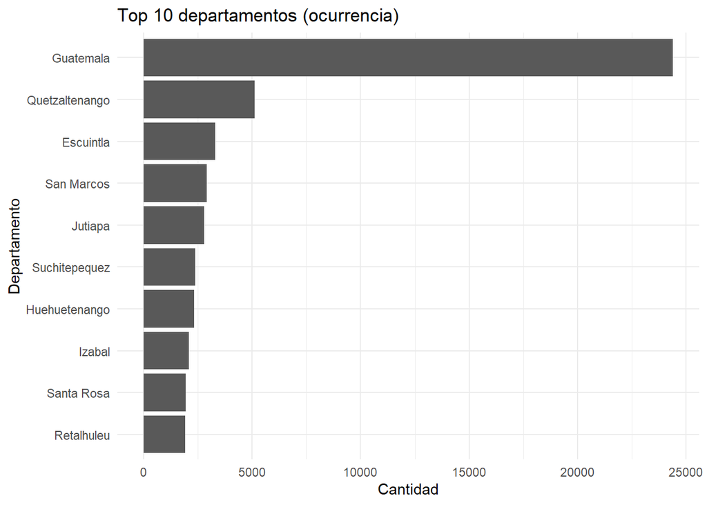

# CLUSTERING

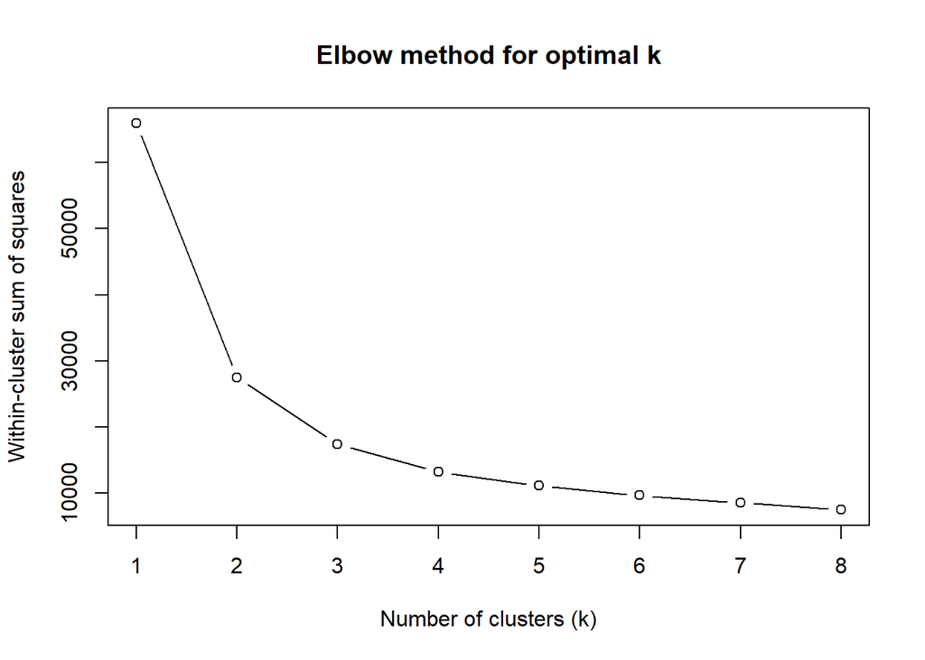

Características de cada cluster (perfiles de edad)

| cluster | n_divorcios | edad_hombre_promedio | edad_mujer_promedio | edad_hombre_sd | edad_mujer_sd |
| --- | --- | --- | --- | --- | --- |
| 4 | 11954 | 27.3 | 24.6 | 3.3 | 3.0 |
| 1 | 12215 | 34.6 | 31.9 | 3.8 | 3.5 |
| 3 | 6457 | 44.1 | 40.3 | 5.2 | 4.7 |
| 2 | 2342 | 58.3 | 52.4 | 7.7 | 7.3 |

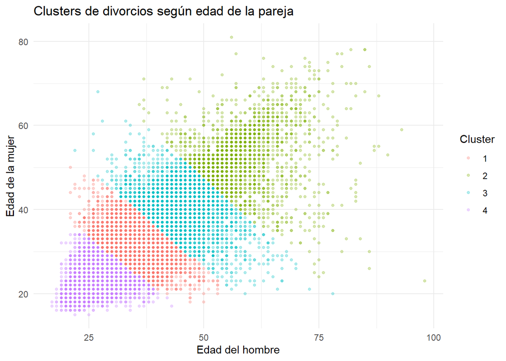

Top 3 departamentos por cluster

| cluster | depocu | n |
| --- | --- | --- |
| 1 | Guatemala | 4472 |
| 1 | Quetzaltenango | 1002 |
| 1 | San Marcos | 569 |
| 2 | Guatemala | 766 |
| 2 | Quetzaltenango | 264 |
| 2 | San Marcos | 132 |
| 3 | Guatemala | 2519 |
| 3 | Quetzaltenango | 620 |
| 3 | San Marcos | 358 |
| 4 | Guatemala | 3154 |
| 4 | Quetzaltenango | 1105 |
| 4 | San Marcos | 608 |

Top 3 etnias (hombre) por cluster

| cluster | pueblo_hom | n |
| --- | --- | --- |
| 1 | Ladino / Mestizo | 9011 |
| 1 | Ignorado | 1689 |
| 1 | Maya | 1385 |
| 2 | Ladino / Mestizo | 1640 |
| 2 | Ignorado | 443 |
| 2 | Maya | 209 |
| 3 | Ladino / Mestizo | 4512 |
| 3 | Ignorado | 1240 |
| 3 | Maya | 583 |
| 4 | Ladino / Mestizo | 8633 |
| 4 | Maya | 2132 |
| 4 | Ignorado | 1036 |

Top 3 etnias (mujer) por cluster

| cluster | pueblo_muj | n |
| --- | --- | --- |
| 1 | Ladino / Mestizo | 9088 |
| 1 | Ignorado | 1706 |
| 1 | Maya | 1280 |
| 2 | Ladino / Mestizo | 1617 |
| 2 | Ignorado | 477 |
| 2 | Maya | 196 |
| 3 | Ladino / Mestizo | 4688 |
| 3 | Ignorado | 1154 |
| 3 | Maya | 522 |
| 4 | Ladino / Mestizo | 8549 |
| 4 | Maya | 1947 |
| 4 | Ignorado | 1221 |

Top 3 niveles educativos (hombre) por cluster

| cluster | eschom | n |
| --- | --- | --- |
| 1 | Diversificado | 4712 |
| 1 | Primaria | 1788 |
| 1 | Universitario | 1585 |
| 2 | Primaria | 576 |
| 2 | Diversificado | 484 |
| 2 | Ninguno | 463 |
| 3 | Diversificado | 1836 |
| 3 | Primaria | 1164 |
| 3 | Universitario | 983 |
| 4 | Diversificado | 5034 |
| 4 | Básico | 2504 |
| 4 | Primaria | 2135 |

Top 3 niveles educativos (mujer) por cluster

| cluster | escmuj | n |
| --- | --- | --- |
| 1 | 4 | 4926 |
| 1 | 2 | 1632 |
| 1 | 5 | 1569 |
| 2 | 2 | 577 |
| 2 | 4 | 564 |
| 2 | 1 | 481 |
| 3 | 4 | 2002 |
| 3 | 2 | 1130 |
| 3 | 5 | 987 |
| 4 | 4 | 4966 |
| 4 | 3 | 2663 |
| 4 | 2 | 2016 |

## Interpretación de los Clusters

### Perfiles Identificados

El análisis de k-means (k=4) identificó cuatro perfiles de edad distintos en las parejas divorciadas:

**Cluster 4 - Parejas Jóvenes** (n=11,954, 36% del total): - Edad promedio: Hombre 27.3 años, Mujer 24.6 años - Educación predominante: Diversificado (42%), seguido de Básico (21%) - Perfil: Parejas que se casaron jóvenes, con educación secundaria/diversificado

**Cluster 1 - Parejas de Edad Media** (n=12,215, 37% del total): - Edad promedio: Hombre 34.6 años, Mujer 31.9 años - Educación predominante: Diversificado (39%), con presencia notable de Universitarios (13%) - Perfil: El grupo más numeroso, con mayor nivel educativo promedio

**Cluster 3 - Parejas Maduras** (n=6,457, 20% del total): - Edad promedio: Hombre 44.1 años, Mujer 40.3 años - Educación predominante: Diversificado (28%), Primaria (18%), Universitario (15%) - Perfil: Parejas con matrimonios más largos antes del divorcio

**Cluster 2 - Parejas Mayores** (n=2,342, 7% del total): - Edad promedio: Hombre 58.3 años, Mujer 52.4 años - Educación predominante: Primaria (25%), Diversificado (21%), Ninguno (20%) - Perfil: Divorcios tardíos, menor nivel educativo que grupos más jóvenes

# — Punto 2 —

## a) Situación problemática

En Guatemala, el divorcio constituye un fenómeno social que refleja transformaciones en la estructura familiar, las dinámicas de género y las condiciones socioeconómicas del país. A lo largo de los años, se ha mantenido la percepción de que los divorcios son más frecuentes en áreas urbanas, que las personas con mayor nivel educativo tienden a divorciarse a edades más avanzadas y que existe una diferencia de edad constante entre hombres y mujeres al momento de la ruptura matrimonial.

Estas afirmaciones suelen basarse en creencias generales y no siempre en análisis estadísticos formales. Dado que el INE dispone de registros históricos detallados de divorcios, resulta necesario analizar sistemáticamente estos datos para identificar si realmente existen patrones demográficos y geográficos significativos que caractericen el fenómeno.

Se plantea la necesidad de explorar los registros de divorcios para determinar cómo se distribuyen según edad, nivel educativo y ubicación territorial, y si estos factores influyen en el comportamiento observado.

## b) Problema científico y objetivos

### Problema científico

¿Existen patrones demográficos, educativos y geográficos significativos que caractericen los divorcios registrados en Guatemala durante el período analizado?

Este problema busca determinar si variables como la edad, el nivel educativo y el departamento influyen en las características del divorcio.

### Objetivo General

Analizar exploratoriamente los registros de divorcios en Guatemala para identificar patrones demográficos, educativos y geográficos en el período estudiado.

### Objetivos Específicos

1. Describir estadísticamente la edad promedio de hombres y mujeres al momento del divorcio.
2. Analizar la relación entre nivel educativo y edad promedio de divorcio.
3. Evaluar la concentración geográfica de divorcios por departamento.
4. Identificar perfiles de divorcio mediante técnicas de clustering.
5. Interpretar las características de los grupos identificados.

## c) Descripción de los datos y proceso de limpieza

El conjunto de datos utilizado proviene del INE y corresponde a registros oficiales de divorcios en formato .sav, integrando más de diez años de información.

Para el análisis fue necesario realizar un proceso de integración y limpieza que incluyó:

- Lectura y unificación de múltiples archivos anuales.
- Estandarización de nombres de variables.
- Homologación de categorías de pertenencia étnica.
- Conversión de variables categóricas a formatos adecuados.
- Tratamiento de valores atípicos en la variable edad con valores mayores a 100 años que fueron reemplazados por NA.
- Revisión y manejo de valores faltantes.

El conjunto final permitió realizar análisis descriptivos, cruces de variables y un análisis de agrupamiento para identificar perfiles característicos de divorcio.

## d) Conclusiones del análisis exploratorio

- Se confirma una diferencia estructural por género: en todos los departamentos del país, los hombres presentan una edad promedio mayor que las mujeres al momento del divorcio. Este patrón se mantiene constante independientemente del territorio.
- Existe una relación positiva entre nivel educativo y edad promedio de divorcio. Las personas con educación universitaria y postgrado tienden a divorciarse a edades más avanzadas. Sin embargo, la superposición entre distribuciones indica que la educación es un factor asociado, pero no determinante.
- El departamento de Guatemala concentra aproximadamente el 35% del total de divorcios registrados. Asimismo, los municipios con mayor número de casos corresponden principalmente a áreas urbanas como Guatemala, Mixco, Villa Nueva y Quetzaltenango, lo que respalda la hipótesis de mayor incidencia en sectores urbanos.
- El análisis de clustering permitió identificar cuatro perfiles diferenciados principalmente por edad:
  - Cluster 4 – Parejas Jóvenes (36%): Hombre 27.3 años, Mujer 24.6 años.
  - Cluster 1 – Parejas de Edad Media (37%): Hombre 34.6 años, Mujer 31.9 años.
  - Cluster 3 – Parejas Maduras (20%): Hombre 44.1 años, Mujer 40.3 años.
  - Cluster 2 – Parejas Mayores (7%): Hombre 58.3 años, Mujer 52.4 años.